# Bionexr: an R package for integrative network-based analysis of gene somatic mutation and gene expression data to identify cancer drivers

Yang Shuai

2016-01-28

Cancer genome projects have generated massive genome and transcriptome sequencing data, which makes tumor-specific alterations such as somatic mutation and gene expression information easily available. To distinguish cancer drivers from passengers, we implement an R package “Bionexr” for integrative network-based analysis of gene somatic mutation and expression data. Bionexr provides these features:

- A protein-protein interaction network (PPIN)-based approach
- A pathway-based appoach
- Visualization of the result in a network view

Bionexr is consisted of four main modules:

- Data Download
- Gene Analysis
- Network Analysis
- Visualization

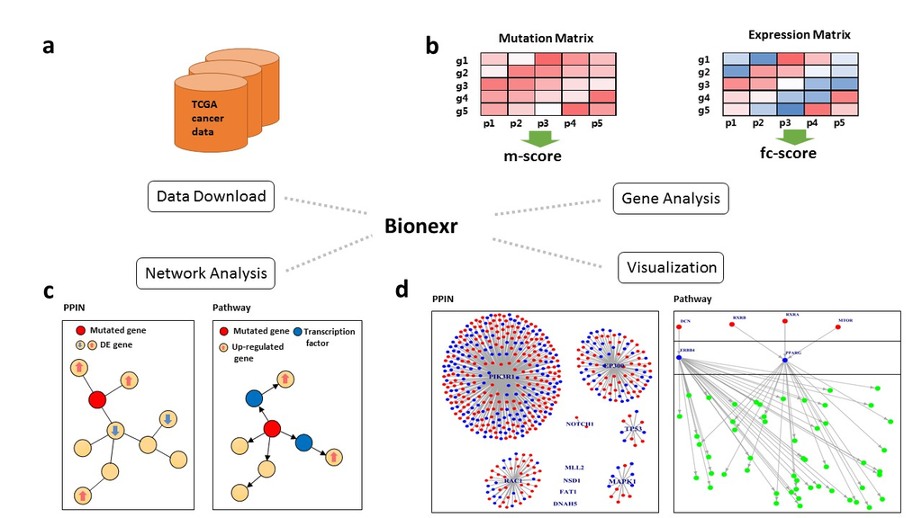

## Quick Start

- First, run the following instructions. Note that if it is the first time to use Bionexr, `prepare_ma()` will take some time to download the dataset used by gene module.

```
library(bionexr)
prepare_ma() # prepare data used by Bionexr
```

- For PPIN-based approach, follow the instructions below:

```
res.gene <- perform_gene_ppi(hnsc_mut_part, hnsc_exp_part)
res.network <- perform_network_ppi(res.gene[[2]], res.gene[[3]])
g <- network_from_ppi(res.network)
plot_ppi(g)
```

And the result would look like below, note that your running result might have a different layout, that’s OK:

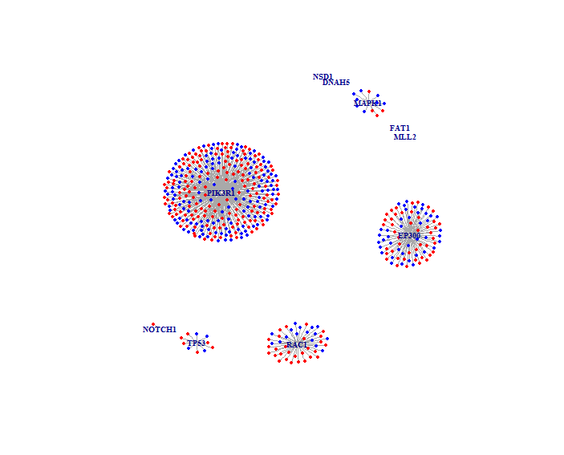

- For pathway-based approach, follow the instructions below:

```
res.gene <- perform_gene_pathway(hnsc_mut_part, hnsc_exp_part)
res.network <- perform_network_pathway(res.gene[[2]], res.gene[[3]], hnsc_expressed_genes)

g <- network_from_significant_branches(res.network)
plot_pathway(g)
```

And the result would look like below, note that your running result might have a different layout, that’s OK:

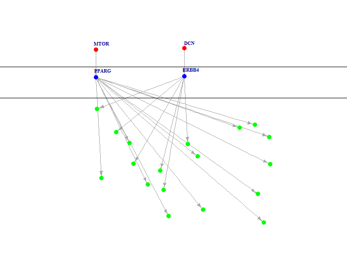

## Usage

### Download cancer genome data using “Data Download” module

`firehose_get` is the main command to download cancer genome data from firehose. Here we use `firehose_get` to download HNSC data.

```
mut_data <- firehose_get("HNSC", "mutation", run_date = "2015_08_21", run_type = "stddata")
mut_data <- mut_data[[1]]
mut_sample_ids <- unique(mut_data[[7]])

exp_data <- firehose_get("HNSC", "expression", run_date = "2015_08_21", run_type = "stddata")
exp_data <- exp_data[[1]]
exp_sample_ids <- colnames(exp_data)

common_case <- intersect(mut_sample_ids, exp_sample_ids)
exp_control <- grepl("-11$", exp_sample_ids)
hnsc_mut <- mut_data[mut_data[[7]] %in% common_case, ]
hnsc_exp <- exp_data[, (exp_sample_ids %in% common_case) | exp_control]
```

### Using “Gene Analysis” module

`perform_gene_ppi` and `perform_gene_pathway` are the two main commands for performing “Gene Analysis”. As you can guess from the function name, `perform_gene_ppi` is for PPIN-based approach and `perform_gene_pathway` is for pathway-based approach.

See the instructions below, note that `hnsc_mut` and `hnsc_exp` are from “Data Download” module:

```
# For PPIN-based approach
ppi.gene <- perform_gene_ppi(hnsc_mut, hnsc_exp)
# For pathway-based approach
pathway.gene <- perform_gene_pathway(hnsc_mut, hnsc_exp)
```

Note that before performing “Gene Analysis”, run command `prepare_ma()` first. This module would take a few time to finish, drink some coffee happily.

### Using “Network Analysis” module

`perform_network_ppi` and `perform_network_pathway` are the two main commands for performing “Network Analysis”. As the same to “Gene Analysis” module, `perform_network_ppi` is for PPIN-based approach and `perform_network_pathway` is for pathway-based approach.

See the instructions below, note that `hnsc_exp` is from “Data Download” module, and `ppi.gene` and `pathway.gene` are from “Gene Analysis” module:

```
# For PPIN-based approach
ppi.network <- perform_network_ppi(ppi.gene[[2]], ppi.gene[[3]])
# For pathway-based approach
expressed_genes <- identify_expressed_genes(hnsc_exp)
pathway.network <- perform_network_pathway(pathway.gene[[2]], pathway.gene[[3]], expressed_genes)
```

### Using “Visualization” module

`plot_ppi` and `plot_pathway` are the two main commands for performing “Visualization” module.`plot_ppi` is for PPIN-based approach’s result and `plot_pathway` is for pathway-based approach’s result.

See the instructions below, note that `ppi.network` and `pathway.network` are from “Network Analysis” module:

```
# For PPIN-based approach's result
ppi.g <- network_from_ppi(ppi.network)
plot_ppi(ppi.g)
# For pathway-based approach's result
pathway.g <- network_from_significant_branches(pathway.network)
plot_pathway(pathway.g)
```

### Using “Gene Analysis” and “Network Analysis” in one command

The commands `perform_main_ppi` and `perform_main_pathway` can perform “Gene Analysis” and “Network Analysis”, and the result can be visualized straightforward.

The example instructions are written below, note that `hnsc_mut` and `hnsc_exp` are from “Data Download” module:

```
# For PPIN-based approach
prepare_ma()
ppi.res <- perform_main_ppi(hnsc_mut, hnsc_exp, jobname = "HNSC", use_cache = TRUE)
# Visualize PPIN-based result
ppi.g <- network_from_ppi(ppi.res)
plot_ppi(ppi.g)

# For pathway-based approach
prepare_ma()
pathway.res <- perform_main_pathway(hnsc_mut, hnsc_exp, jobname = "HNSC", test = TRUE)
pathway.g <- network_from_significant_branches(pathway.res)
plot_pathway(pathway.g)
```

## Contact

Please send email to yannis.pku@gmail.com if you have any questions.